# A stochastic meta-population model of LSDV epidemics

Thibaut Jombart

## Outline of the work

In this report, we use a stochastic, meta-population SEIRCDV model to simulate outbreaks of Lumpy skin disease virus. We contrast different response scenario:

1. **baseline**: no response
2. **cull_quarant_vacc scenario**: mass culling of infected farms, quarantine (local and ring), ring vaccination
3. **quarant_vacc**: quarantine (local and ring) and vaccination (local and ring)
4. **selcull_quarant_vacc**: selective culling (only individuals in $I$), quarantine (local and ring) and vaccination (local and ring)
5. **selcull_quarant_vacc_insect scenario**: all but mass culling (selective culling, vaccination, quarantine, insecticide)
6. **all**: all measures combined

## Simulation setup

### Required libraries

We load required libraries:

```r
library(tidyverse)
library(viridis)
```

```r
library(qs)
## qs 0.27.3. Announcement: https://github.com/qsbase/qs/issues/103
library(here)
## here() starts at C:/dev/lsdsim
library(digest)
library(compiler)
library(rio)
library(cowplot)
devtools::load_all()
## ℹ Loading lsdsim
```

## Population setting

```r
n_rep <- params$n_rep
duration <- 365
grid_size <- 40
n_pop <- grid_size^2
xy <- make_grid(grid_size)
delta <- make_delta(xy, diffusion = 0.05)
```

The size of the farms, in number of herds, is drawn using an average herd size of 50, exponentially distributed with a minimum at 20 individuals:

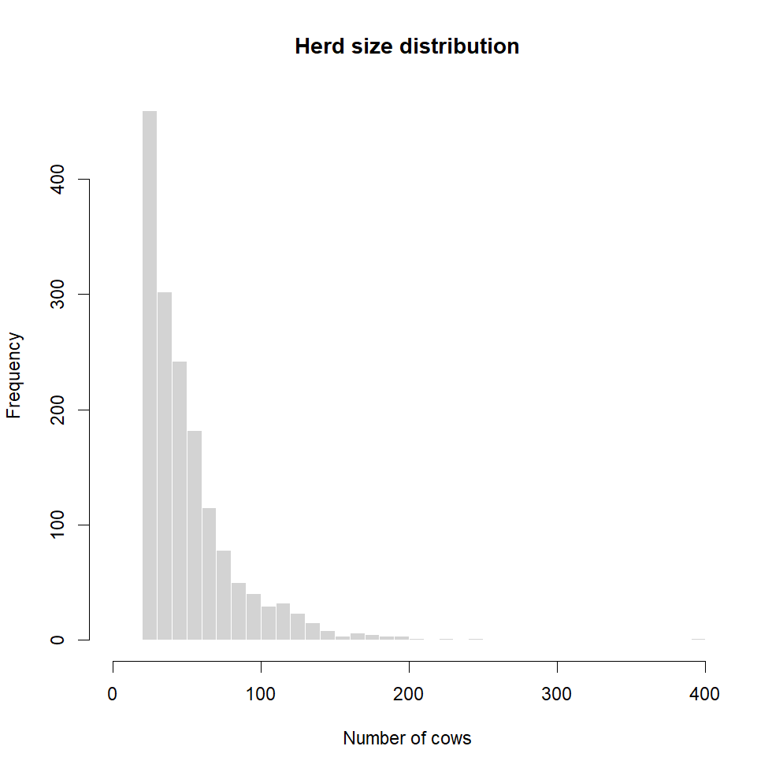

```r
r_herd_size <- function(n) {
  20 + round(rexp(nrow(xy), 1/30))
}

herd_size <- r_herd_size(1e4)
hist(herd_size, border = "white",
     main = "Herd size distribution",
     xlab = "Number of cows",
     nclass = 30,
     xlim = c(0, max(herd_size)))
```

```r
summary(herd_size)
```

```
##    Min. 1st Qu.  Median    Mean 3rd Qu.    Max.
##   20.00   29.00   42.00   51.13   61.25  398.00
```

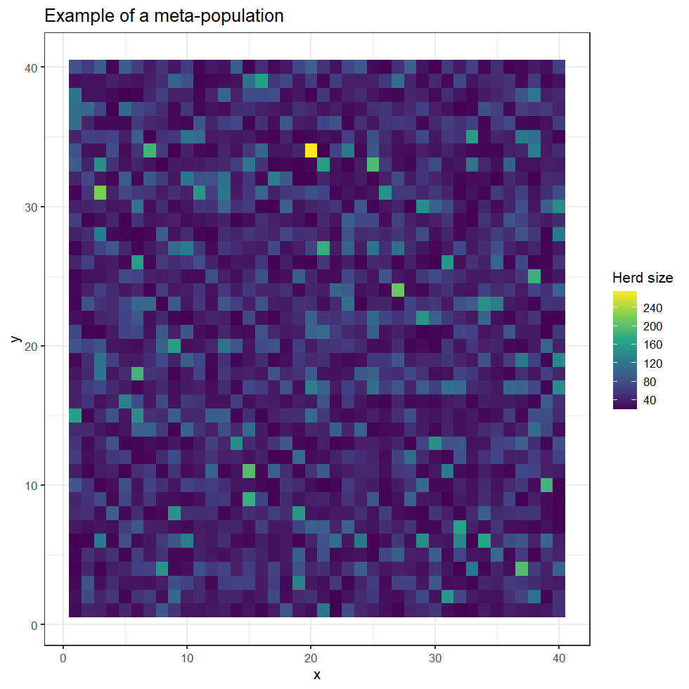

```r
herds <- cbind.data.frame(xy, size = r_herd_size(n_pop))

ggplot(herds, aes(x = x, y = y)) +
  geom_tile(aes(fill = size)) +
  theme_bw() +
  scale_fill_viridis_c("Herd size", n.breaks = 8) +
  labs(title = "Example of a meta-population")
```

In practice, every simulation will use a different population setting (randomly drawn herd sizes).

## Simulations

### General settings

We set the number of replicates, which will apply to each simulation scenario. We also make a compiled version of `lsdsim` and set up initial conditions.

```r
fast_lsdsim <- compiler::cmpfun(lsdsim)
```

This function is used to generate one new case in a randomly chosen population, to seed outbreaks:

```r
r_ini_case <- function(n_pop) {
  out <- rep(0, n_pop)
  out[sample.int(n_pop, 1)] <- 1
  out
}
```

Input parameters will be the same for different interventions:

```r
lsd_params <- rlsd_param(n_rep)
head(lsd_params)
```

```
##          R0   latent infec_period        cfr     beta     sigma     gamma
## 1 10.185411 8.196938     9.341819 0.02578571 1.090303 0.1219968 0.1070455
## 2 10.149335 8.377204     8.954969 0.01612551 1.133375 0.1193716 0.1116698
## 3  9.863644 8.328853     9.168501 0.02632604 1.075819 0.1200645 0.1090691
## 4 10.464956 7.606614     8.620544 0.02727598 1.213955 0.1314645 0.1160020
## 5  9.513808 8.212039     8.810525 0.02269231 1.079823 0.1217724 0.1135006
## 6  9.396505 7.420712     8.271991 0.02543027 1.135942 0.1347580 0.1208899
```

```r
list_herd_size <- lapply(1:n_rep, function(i) r_herd_size(n_pop))
list_ini_cases <- lapply(1:n_rep, function(i) r_ini_case(n_pop))

inputs <- tibble(
  lsd_params,
  ini_S = list_herd_size,
  ini_I = list_ini_cases
)

inputs$label <- apply(inputs, 1, function(e) substr(digest(e), 1, 8))
```

### *baseline* scenario: no response

In these simulations, we use no response.

```r
output_dir <- here::here("outputs", "simulations", "baseline", Sys.Date())
if (!dir.exists(output_dir)) {
  dir.create(output_dir, recursive = TRUE)
}

res_baseline <- vector(mode = "list", length = n_rep)
for (i in seq_len(n_rep)) {
  ## run simulation
  current_sim <- fast_lsdsim(
    grid_size = grid_size,
    time = duration,
    ini_S = unlist(inputs$ini_S[[i]]),
    ini_I = unlist(inputs$ini_I[[i]]),
    delta = delta,
    beta = inputs$beta[i],
    sigma = inputs$sigma[i],
    gamma = inputs$gamma[i],
    cfr = inputs$cfr[i],
    quarantine = FALSE,
    vaccination = FALSE,
    mass_culling = FALSE,
    select_culling = FALSE,
    insecticide = FALSE
  )

  ## save full simulation to file
  out_file <- file.path(
    output_dir,
    paste0(inputs$label[i], "_baseline", ".qs")
  )
  qsave(current_sim, out_file)

  ## store summary
  res_baseline[[i]] <- summary(current_sim)[duration, ]
}

res_baseline <- cbind(label = inputs$label, bind_rows(res_baseline))
head(res_baseline)
```

```
##      label time     S    E    I    D C     R V     N new_I total_cases
## 1 a8593949  365 53813  999 1102  571 0 21806 0 77720   129       23479
## 2 0fb5a711  365 58350  998 1124  297 0 20014 0 80486   122       21435
## 3 23cdd14f  365 52893  992 1181  652 0 24130 0 79196   110       25963
## 4 a4e828d5  365 38264 1307 1641 1093 0 38219 0 79431   190       40953
## 5 78ea7710  365 50208 1267 1311  557 0 25583 0 78369   149       27451
## 6 1643fcce  365 46561 1028 1044  760 0 28100 0 76733   116       29904
##          ar n_pop_infec n_pop_ever_infec n_naive n_response n_ring total_naive
## 1 0.3020973         140              544    1600          0      0      584000
## 2 0.2663196         140              459    1600          0      0      584000
## 3 0.3278322         159              566    1600          0      0      584000
## 4 0.5155796         232              891    1600          0      0      584000
## 5 0.3502788         199              610    1600          0      0      584000
## 6 0.3897150         179              687    1600          0      0      584000
##   total_response total_ring
## 1              0          0
## 2              0          0
## 3              0          0
## 4              0          0
## 5              0          0
## 6              0          0
```

```r
summary(res_baseline)
```

```
##     label                time           S               E
##  Length:30          Min.   :365   Min.   :38264   Min.   :   0.0
##  Class :character   1st Qu.:365   1st Qu.:48280   1st Qu.: 754.2
##  Mode  :character   Median :365   Median :53659   Median : 982.5
##                     Mean   :365   Mean   :55186   Mean   : 935.0
##                     3rd Qu.:365   3rd Qu.:59867   3rd Qu.:1129.8
##                     Max.   :365   Max.   :80900   Max.   :1792.0
##        I              D                C           R               V
##  Min.   :   0   Min.   :   0.0   Min.   :0   Min.   :    1   Min.   :0
##  1st Qu.: 815   1st Qu.: 422.5   1st Qu.:0   1st Qu.:18086   1st Qu.:0
##  Median :1060   Median : 580.5   Median :0   Median :22861   Median :0
##  Mean   :1020   Mean   : 619.9   Mean   :0   Mean   :22097   Mean   :0
##  3rd Qu.:1186   3rd Qu.: 819.5   3rd Qu.:0   3rd Qu.:28636   3rd Qu.:0
##  Max.   :1817   Max.   :1363.0   Max.   :0   Max.   :38219   Max.   :0
##        N             new_I        total_cases          ar
##  Min.   :76189   Min.   :  0.0   Min.   :    1   Min.   :1.236e-05
##  1st Qu.:78371   1st Qu.: 89.5   1st Qu.:19182   1st Qu.:2.422e-01
##  Median :79314   Median :113.5   Median :24695   Median :3.130e-01
##  Mean   :79238   Mean   :111.2   Mean   :23737   Mean   :2.994e-01
##  3rd Qu.:80248   3rd Qu.:143.8   3rd Qu.:30688   3rd Qu.:3.890e-01
##  Max.   :81239   Max.   :191.0   Max.   :40953   Max.   :5.156e-01
##   n_pop_infec    n_pop_ever_infec    n_naive       n_response     n_ring
##  Min.   :  0.0   Min.   :  1.0    Min.   :1600   Min.   :0    Min.   :0
##  1st Qu.:122.2   1st Qu.:417.2    1st Qu.:1600   1st Qu.:0    1st Qu.:0
##  Median :142.5   Median :542.5    Median :1600   Median :0    Median :0
##  Mean   :141.0   Mean   :516.6    Mean   :1600   Mean   :0    Mean   :0
##  3rd Qu.:167.2   3rd Qu.:652.5    3rd Qu.:1600   3rd Qu.:0    3rd Qu.:0
##  Max.   :252.0   Max.   :891.0    Max.   :1600   Max.   :0    Max.   :0
##   total_naive     total_response   total_ring
##  Min.   :584000   Min.   :0      Min.   :0
##  1st Qu.:584000   1st Qu.:0      1st Qu.:0
##  Median :584000   Median :0      Median :0
##  Mean   :584000   Mean   :0      Mean   :0
##  3rd Qu.:584000   3rd Qu.:0      3rd Qu.:0
##  Max.   :584000   Max.   :0      Max.   :0
```

```r
qsave(res_baseline, file.path(output_dir, "summary.qs"))
rio::export(res_baseline, file.path(output_dir, "summary.xlsx"))
```

### *cull_quarant_vacc* scenario: mass culling and ring vaccination

In these simulations, we use:

- mass culling of the affected herds
- ring vaccination (i.e. vaccination of neighbours)

```r
output_dir <- here::here("outputs", "simulations", "cull_quarant_vacc", Sys.Date())
if (!dir.exists(output_dir)) {
  dir.create(output_dir, recursive = TRUE)
}

res_cull_quarant_vacc <- vector(mode = "list", length = n_rep)
for (i in seq_len(n_rep)) {
  ## run simulation
  current_sim <- fast_lsdsim(
    grid_size = grid_size,
    time = duration,
    ini_S = unlist(inputs$ini_S[[i]]),
    ini_I = unlist(inputs$ini_I[[i]]),
    delta = delta,
    beta = inputs$beta[i],
    sigma = inputs$sigma[i],
    gamma = inputs$gamma[i],
    cfr = inputs$cfr[i],
    quarantine = TRUE,
    vaccination = TRUE,
    mass_culling = TRUE,
    select_culling = FALSE,
    insecticide = FALSE,
    interv_delay = 4,
    interv_release = 28,
    quarant_efficacy_in = 0.2,
    quarant_efficacy_out = 0.9,
    vacc_coverage = 1,
    vacc_efficacy = 0.65/21,
    rate_cull = 0.5
  )

  ## save full simulation to file
  out_file <- file.path(
    output_dir,
    paste0(inputs$label[i], "_cull_quarant_vacc", ".qs")
  )
  qsave(current_sim, out_file)

  ## store summary
  res_cull_quarant_vacc[[i]] <- summary(current_sim)[duration, ]
}

res_cull_quarant_vacc <- cbind(label = inputs$label, bind_rows(res_cull_quarant_vacc))
head(res_cull_quarant_vacc)
```

```
##      label time     S E I D  C R   V     N new_I total_cases           ar
## 1 a8593949  365 78130 0 0 0 38 0 123 78253     0           1 1.277906e-05
## 2 0fb5a711  365 80654 0 0 0 40 0  89 80743     0           1 1.238497e-05
## 3 23cdd14f  365 79721 0 0 0 49 0  78 79799     0           1 1.253149e-05
## 4 a4e828d5  365 80329 0 0 0 92 0 103 80432     0           3 3.729859e-05
## 5 78ea7710  365 78728 0 0 0 57 0 141 78869     0           3 3.803776e-05
## 6 1643fcce  365 77178 0 0 0 31 0 284 77462     0           2 2.581911e-05
##   n_pop_infec n_pop_ever_infec n_naive n_response n_ring total_naive
## 1           0                1    1600          0      0      583855
## 2           0                1    1600          0      0      583896
## 3           0                1    1600          0      0      583855
## 4           0                1    1600          0      0      583840
## 5           0                1    1600          0      0      583840
## 6           0                1    1600          0      0      583820
##   total_response total_ring
## 1             29        116
## 2             26         78
## 3             29        116
## 4             32        128
## 5             32        128
## 6             36        144
```

```r
summary(res_cull_quarant_vacc)
```

```
##     label                time           S               E           I
##  Length:30          Min.   :365   Min.   :76024   Min.   :0   Min.   :0
##  Class :character   1st Qu.:365   1st Qu.:78849   1st Qu.:0   1st Qu.:0
##  Mode  :character   Median :365   Median :80046   Median :0   Median :0
##                     Mean   :365   Mean   :79685   Mean   :0   Mean   :0
##                     3rd Qu.:365   3rd Qu.:80571   3rd Qu.:0   3rd Qu.:0
##                     Max.   :365   Max.   :81654   Max.   :0   Max.   :0
##        D             C                R           V                N
##  Min.   :0.0   Min.   : 23.00   Min.   :0   Min.   : 53.00   Min.   :76131
##  1st Qu.:0.0   1st Qu.: 33.00   1st Qu.:0   1st Qu.: 94.75   1st Qu.:78975
##  Median :0.0   Median : 41.00   Median :0   Median :119.00   Median :80145
##  Mean   :0.1   Mean   : 49.00   Mean   :0   Mean   :124.17   Mean   :79809
##  3rd Qu.:0.0   3rd Qu.: 58.75   3rd Qu.:0   3rd Qu.:140.75   3rd Qu.:80676
##  Max.   :1.0   Max.   :102.00   Max.   :0   Max.   :284.00   Max.   :81761
##      new_I    total_cases          ar             n_pop_infec n_pop_ever_infec
##  Min.   :0   Min.   :1.000   Min.   :1.227e-05   Min.   :0    Min.   :1.000
##  1st Qu.:0   1st Qu.:1.000   1st Qu.:1.258e-05   1st Qu.:0    1st Qu.:1.000
##  Median :0   Median :2.000   Median :2.478e-05   Median :0    Median :1.000
##  Mean   :0   Mean   :2.033   Mean   :2.546e-05   Mean   :0    Mean   :1.067
##  3rd Qu.:0   3rd Qu.:3.000   3rd Qu.:3.728e-05   3rd Qu.:0    3rd Qu.:1.000
##  Max.   :0   Max.   :5.000   Max.   :6.175e-05   Max.   :0    Max.   :2.000
##     n_naive       n_response     n_ring   total_naive     total_response
##  Min.   :1600   Min.   :0    Min.   :0   Min.   :583738   Min.   :26.0
##  1st Qu.:1600   1st Qu.:0    1st Qu.:0   1st Qu.:583840   1st Qu.:29.0
##  Median :1600   Median :0    Median :0   Median :583847   Median :31.0
##  Mean   :1600   Mean   :0    Mean   :0   Mean   :583843   Mean   :32.8
##  3rd Qu.:1600   3rd Qu.:0    3rd Qu.:0   3rd Qu.:583859   3rd Qu.:33.5
##  Max.   :1600   Max.   :0    Max.   :0   Max.   :583896   Max.   :64.0
##    total_ring
##  Min.   : 78.0
##  1st Qu.:112.5
##  Median :122.0
##  Mean   :124.3
##  3rd Qu.:128.0
##  Max.   :198.0
```

```r
qsave(res_cull_quarant_vacc, file.path(output_dir, "summary.qs"))
rio::export(res_cull_quarant_vacc, file.path(output_dir, "summary.xlsx"))
```

### *quarant_vacc* scenario: quarantine and ring vaccination

In these simulations, we use:

- quarantine of infected herds and neighbours
- vaccination of infected herds and neighbours

```r
output_dir <- here::here("outputs", "simulations", "quarant_vacc", Sys.Date())
if (!dir.exists(output_dir)) {
  dir.create(output_dir, recursive = TRUE)
}

res_quarant_vacc <- vector(mode = "list", length = n_rep)
for (i in seq_len(n_rep)) {
  ## run simulation
  current_sim <- fast_lsdsim(
    grid_size = grid_size,
    time = duration,
    ini_S = unlist(inputs$ini_S[[i]]),
    ini_I = unlist(inputs$ini_I[[i]]),
    delta = delta,
    beta = inputs$beta[i],
    sigma = inputs$sigma[i],
    gamma = inputs$gamma[i],
    cfr = inputs$cfr[i],
    quarantine = TRUE,
    vaccination = TRUE,
    mass_culling = FALSE,
    select_culling = FALSE,
    insecticide = FALSE,
    interv_delay = 4,
    interv_release = 28,
    quarant_efficacy_in = 0.2,
    quarant_efficacy_out = 0.9,
    vacc_coverage = 1,
    vacc_efficacy = 0.65/21
  )

  ## save full simulation to file
  out_file <- file.path(
    output_dir,
    paste0(inputs$label[i], "_quarant_vacc", ".qs")
  )
  qsave(current_sim, out_file)

  ## store summary
  res_quarant_vacc[[i]] <- summary(current_sim)[duration, ]
}

res_quarant_vacc <- cbind(label = inputs$label, bind_rows(res_quarant_vacc))
head(res_quarant_vacc)
```

```
##      label time     S E I D C  R   V     N new_I total_cases           ar
## 1 a8593949  365 78042 0 0 0 0 26 223 78291     0          26 3.320944e-04
## 2 0fb5a711  365 80329 0 0 1 0 43 410 80782     0          44 5.446758e-04
## 3 23cdd14f  365 79501 0 0 2 0 41 304 79846     0          43 5.385367e-04
## 4 a4e828d5  365 80274 0 0 0 0 22 228 80524     0          22 2.732105e-04
## 5 78ea7710  365 78630 0 0 0 0 26 270 78926     0          26 3.294225e-04
## 6 1643fcce  365 77247 0 0 0 0  1 245 77493     0           1 1.290439e-05
##   n_pop_infec n_pop_ever_infec n_naive n_response n_ring total_naive
## 1           0                1    1600          0      0      583540
## 2           0                5    1600          0      0      583170
## 3           0                2    1600          0      0      583253
## 4           0                1    1600          0      0      583390
## 5           0                1    1600          0      0      583300
## 6           0                1    1600          0      0      583870
##   total_response total_ring
## 1             92        368
## 2            287        543
## 3            163        584
## 4            122        488
## 5            140        560
## 6             26        104
```

```r
summary(res_quarant_vacc)
```

```
##     label                time           S               E           I
##  Length:30          Min.   :365   Min.   :75957   Min.   :0   Min.   :0
##  Class :character   1st Qu.:365   1st Qu.:78761   1st Qu.:0   1st Qu.:0
##  Mode  :character   Median :365   Median :79918   Median :0   Median :0
##                     Mean   :365   Mean   :79553   Mean   :0   Mean   :0
##                     3rd Qu.:365   3rd Qu.:80350   3rd Qu.:0   3rd Qu.:0
##                     Max.   :365   Max.   :81489   Max.   :0   Max.   :0
##        D                C           R               V               N
##  Min.   :0.0000   Min.   :0   Min.   : 1.00   Min.   :122.0   Min.   :76187
##  1st Qu.:0.0000   1st Qu.:0   1st Qu.:23.00   1st Qu.:214.8   1st Qu.:79036
##  Median :1.0000   Median :0   Median :31.00   Median :266.0   Median :80203
##  Mean   :0.9667   Mean   :0   Mean   :33.23   Mean   :270.4   Mean   :79857
##  3rd Qu.:1.7500   3rd Qu.:0   3rd Qu.:40.75   3rd Qu.:307.0   3rd Qu.:80715
##  Max.   :4.0000   Max.   :0   Max.   :98.00   Max.   :511.0   Max.   :81802
##      new_I    total_cases          ar             n_pop_infec n_pop_ever_infec
##  Min.   :0   Min.   :  1.0   Min.   :0.0000129   Min.   :0    Min.   :1.000
##  1st Qu.:0   1st Qu.: 23.0   1st Qu.:0.0002929   1st Qu.:0    1st Qu.:1.000
##  Median :0   Median : 31.5   Median :0.0003926   Median :0    Median :1.500
##  Mean   :0   Mean   : 34.2   Mean   :0.0004269   Mean   :0    Mean   :1.767
##  3rd Qu.:0   3rd Qu.: 41.5   3rd Qu.:0.0005215   3rd Qu.:0    3rd Qu.:2.000
##  Max.   :0   Max.   :102.0   Max.   :0.0012513   Max.   :0    Max.   :5.000
##     n_naive       n_response     n_ring   total_naive     total_response
##  Min.   :1600   Min.   :0    Min.   :0   Min.   :582908   Min.   : 26.00
##  1st Qu.:1600   1st Qu.:0    1st Qu.:0   1st Qu.:583252   1st Qu.: 92.75
##  Median :1600   Median :0    Median :0   Median :583415   Median :128.50
##  Mean   :1600   Mean   :0    Mean   :0   Mean   :583393   Mean   :141.90
##  3rd Qu.:1600   3rd Qu.:0    3rd Qu.:0   3rd Qu.:583563   3rd Qu.:178.75
##  Max.   :1600   Max.   :0    Max.   :0   Max.   :583870   Max.   :287.00
##    total_ring
##  Min.   :104.0
##  1st Qu.:350.0
##  Median :454.0
##  Mean   :464.9
##  3rd Qu.:569.0
##  Max.   :817.0
```

```r
qsave(res_quarant_vacc, file.path(output_dir, "summary.qs"))
rio::export(res_quarant_vacc, file.path(output_dir, "summary.xlsx"))
```

### *selcull_quarant_vacc* scenario: selective culling, quarantine and ring vaccination

In these simulations, we use:

- selective culling of infected individuals
- quarantine of infected herds and neighbours
- vaccination of infected herds and neighbours

```r
output_dir <- here::here("outputs", "simulations", "quarant_vacc", Sys.Date())
if (!dir.exists(output_dir)) {
  dir.create(output_dir, recursive = TRUE)
}

res_selcull_quarant_vacc <- vector(mode = "list", length = n_rep)
for (i in seq_len(n_rep)) {
  ## run simulation
  current_sim <- fast_lsdsim(
    grid_size = grid_size,
    time = duration,
    ini_S = unlist(inputs$ini_S[[i]]),
    ini_I = unlist(inputs$ini_I[[i]]),
    delta = delta,
    beta = inputs$beta[i],
    sigma = inputs$sigma[i],
    gamma = inputs$gamma[i],
    cfr = inputs$cfr[i],
    quarantine = TRUE,
    vaccination = TRUE,
    mass_culling = FALSE,
    select_culling = TRUE,
    insecticide = FALSE,
    interv_delay = 4,
    interv_release = 28,
    quarant_efficacy_in = 0.2,
    quarant_efficacy_out = 0.9,
    vacc_coverage = 1,
    vacc_efficacy = 0.65/21,
    rate_cull = 1e30 # immediate culling
  )

  ## save full simulation to file
  out_file <- file.path(
    output_dir,
    paste0(inputs$label[i], "_selcull_quarant_vacc", ".qs")
  )
  qsave(current_sim, out_file)

  ## store summary
  res_selcull_quarant_vacc [[i]] <- summary(current_sim)[duration, ]
}

res_selcull_quarant_vacc  <- cbind(
  label = inputs$label,
  bind_rows(res_selcull_quarant_vacc )
)

head(res_selcull_quarant_vacc )
```

```
##      label time     S E I D  C R   V     N new_I total_cases           ar
## 1 a8593949  365 78047 0 0 0 16 0 228 78275     0          16 0.0002044075
## 2 0fb5a711  365 80617 0 0 0 10 0 156 80773     0          10 0.0001238037
## 3 23cdd14f  365 79686 0 0 0 21 0 141 79827     0          21 0.0002630689
## 4 a4e828d5  365 80306 0 0 0  9 0 209 80515     0           9 0.0001117804
## 5 78ea7710  365 78579 0 0 0  9 1 337 78917     0          10 0.0001267154
## 6 1643fcce  365 76990 0 0 0 13 0 490 77480     0          13 0.0001677852
##   n_pop_infec n_pop_ever_infec n_naive n_response n_ring total_naive
## 1           0                1    1600          0      0      583500
## 2           0                1    1600          0      0      583708
## 3           0                1    1600          0      0      583680
## 4           0                1    1600          0      0      583715
## 5           0                2    1600          0      0      583629
## 6           0                2    1600          0      0      583416
##   total_response total_ring
## 1            100        400
## 2             73        219
## 3             64        256
## 4             57        228
## 5             89        282
## 6            138        446
```

```r
summary(res_selcull_quarant_vacc)
```

```
##     label                time           S               E           I
##  Length:30          Min.   :365   Min.   :75975   Min.   :0   Min.   :0
##  Class :character   1st Qu.:365   1st Qu.:78770   1st Qu.:0   1st Qu.:0
##  Mode  :character   Median :365   Median :79958   Median :0   Median :0
##                     Mean   :365   Mean   :79628   Mean   :0   Mean   :0
##                     3rd Qu.:365   3rd Qu.:80550   3rd Qu.:0   3rd Qu.:0
##                     Max.   :365   Max.   :81619   Max.   :0   Max.   :0
##        D           C                R                V               N
##  Min.   :0   Min.   : 2.000   Min.   :0.0000   Min.   :131.0   Min.   :76174
##  1st Qu.:0   1st Qu.: 4.500   1st Qu.:0.0000   1st Qu.:148.8   1st Qu.:79029
##  Median :0   Median : 9.000   Median :0.0000   Median :196.5   Median :80196
##  Mean   :0   Mean   : 9.667   Mean   :0.2667   Mean   :220.2   Mean   :79848
##  3rd Qu.:0   3rd Qu.:12.750   3rd Qu.:0.0000   3rd Qu.:227.5   3rd Qu.:80708
##  Max.   :0   Max.   :35.000   Max.   :2.0000   Max.   :603.0   Max.   :81796
##      new_I    total_cases           ar             n_pop_infec n_pop_ever_infec
##  Min.   :0   Min.   : 2.000   Min.   :2.486e-05   Min.   :0    Min.   :1.0
##  1st Qu.:0   1st Qu.: 5.250   1st Qu.:6.709e-05   1st Qu.:0    1st Qu.:1.0
##  Median :0   Median : 9.000   Median :1.115e-04   Median :0    Median :1.0
##  Mean   :0   Mean   : 9.933   Mean   :1.249e-04   Mean   :0    Mean   :1.3
##  3rd Qu.:0   3rd Qu.:12.750   3rd Qu.:1.585e-04   3rd Qu.:0    3rd Qu.:1.0
##  Max.   :0   Max.   :37.000   Max.   :4.720e-04   Max.   :0    Max.   :5.0
##     n_naive       n_response     n_ring   total_naive     total_response
##  Min.   :1600   Min.   :0    Min.   :0   Min.   :583114   Min.   : 35.00
##  1st Qu.:1600   1st Qu.:0    1st Qu.:0   1st Qu.:583626   1st Qu.: 48.25
##  Median :1600   Median :0    Median :0   Median :583699   Median : 62.50
##  Mean   :1600   Mean   :0    Mean   :0   Mean   :583662   Mean   : 74.53
##  3rd Qu.:1600   3rd Qu.:0    3rd Qu.:0   3rd Qu.:583759   3rd Qu.: 83.25
##  Max.   :1600   Max.   :0    Max.   :0   Max.   :583860   Max.   :242.00
##    total_ring
##  Min.   :105.0
##  1st Qu.:193.0
##  Median :238.0
##  Mean   :263.4
##  3rd Qu.:295.5
##  Max.   :644.0
```

```r
qsave(res_selcull_quarant_vacc, file.path(output_dir, "summary.qs"))
rio::export(res_selcull_quarant_vacc, file.path(output_dir, "summary.xlsx"))
```

### *selcull_quarant_vacc_insect* scenario: selective culling, quarantine, ring vaccination, insecticide (all but mass culling)

In these simulations, we use:

- selective culling of infected individuals
- quarantine of infected herds and neighbours
- vaccination of infected herds and neighbours
- insecticide spray of infected herds and neighbours

```r
output_dir <- here::here("outputs", "simulations", "selcull_quarant_vacc_insect", Sys.Date())
if (!dir.exists(output_dir)) {
  dir.create(output_dir, recursive = TRUE)
}

res_selcull_quarant_vacc_insect <- vector(mode = "list", length = n_rep)
for (i in seq_len(n_rep)) {
  ## run simulation
  current_sim <- fast_lsdsim(
    grid_size = grid_size,
    time = duration,
    ini_S = unlist(inputs$ini_S[[i]]),
    ini_I = unlist(inputs$ini_I[[i]]),
    delta = delta,
    beta = inputs$beta[i],
    sigma = inputs$sigma[i],
    gamma = inputs$gamma[i],
    cfr = inputs$cfr[i],
    quarantine = TRUE,
    vaccination = TRUE,
    mass_culling = FALSE,
    select_culling = TRUE,
    insecticide = TRUE,
    interv_delay = 4,
    interv_release = 28,
    vacc_coverage = 1,
    vacc_efficacy = 0.65/21,
    quarant_efficacy_in = 0.2,
    quarant_efficacy_out = 0.9,
    rate_cull = 1e30,
    insect_efficacy = 0.5
  )

  ## save full simulation to file
  out_file <- file.path(
    output_dir,
    paste0(inputs$label[i], "_selcull_quarant_vacc_insect", ".qs")
  )
  qsave(current_sim, out_file)

  ## store summary
  res_selcull_quarant_vacc_insect[[i]] <- summary(current_sim)[duration, ]
}

res_selcull_quarant_vacc_insect <- cbind(label = inputs$label, bind_rows(res_selcull_quarant_vacc_insect))
head(res_selcull_quarant_vacc_insect)
```

```
##      label time     S E I D C R   V     N new_I total_cases           ar
## 1 a8593949  365 78080 0 0 0 7 0 204 78284     0           7 8.941802e-05
## 2 0fb5a711  365 80646 0 0 0 3 0 134 80780     0           3 3.713791e-05
## 3 23cdd14f  365 79693 0 0 0 9 0 146 79839     0           9 1.127269e-04
## 4 a4e828d5  365 80314 0 0 0 8 0 202 80516     0           8 9.935913e-05
## 5 78ea7710  365 78761 0 0 0 0 1 164 78926     0           1 1.267010e-05
## 6 1643fcce  365 77028 0 0 0 5 2 458 77488     0           7 9.033657e-05
##   n_pop_infec n_pop_ever_infec n_naive n_response n_ring total_naive
## 1           0                1    1600          0      0      583765
## 2           0                1    1600          0      0      583840
## 3           0                1    1600          0      0      583705
## 4           0                1    1600          0      0      583730
## 5           0                1    1600          0      0      583870
## 6           0                2    1600          0      0      583526
##   total_response total_ring
## 1             47        188
## 2             40        120
## 3             59        236
## 4             54        216
## 5             26        104
## 6            102        372
```

```r
summary(res_selcull_quarant_vacc_insect)
```

```
##     label                time           S               E           I
##  Length:30          Min.   :365   Min.   :75990   Min.   :0   Min.   :0
##  Class :character   1st Qu.:365   1st Qu.:78850   1st Qu.:0   1st Qu.:0
##  Mode  :character   Median :365   Median :79936   Median :0   Median :0
##                     Mean   :365   Mean   :79635   Mean   :0   Mean   :0
##                     3rd Qu.:365   3rd Qu.:80498   3rd Qu.:0   3rd Qu.:0
##                     Max.   :365   Max.   :81641   Max.   :0   Max.   :0
##        D           C                R                V               N
##  Min.   :0   Min.   : 0.000   Min.   :0.0000   Min.   :131.0   Min.   :76181
##  1st Qu.:0   1st Qu.: 3.250   1st Qu.:0.0000   1st Qu.:164.8   1st Qu.:79034
##  Median :0   Median : 7.000   Median :0.0000   Median :181.0   Median :80198
##  Mean   :0   Mean   : 6.533   Mean   :0.3667   Mean   :216.0   Mean   :79851
##  3rd Qu.:0   3rd Qu.: 8.000   3rd Qu.:1.0000   3rd Qu.:222.2   3rd Qu.:80710
##  Max.   :0   Max.   :16.000   Max.   :2.0000   Max.   :458.0   Max.   :81795
##      new_I    total_cases          ar             n_pop_infec n_pop_ever_infec
##  Min.   :0   Min.   : 1.00   Min.   :1.267e-05   Min.   :0    Min.   :1.000
##  1st Qu.:0   1st Qu.: 4.00   1st Qu.:4.971e-05   1st Qu.:0    1st Qu.:1.000
##  Median :0   Median : 7.00   Median :8.988e-05   Median :0    Median :1.000
##  Mean   :0   Mean   : 6.90   Mean   :8.645e-05   Mean   :0    Mean   :1.333
##  3rd Qu.:0   3rd Qu.: 8.75   3rd Qu.:1.081e-04   3rd Qu.:0    3rd Qu.:1.000
##  Max.   :0   Max.   :16.00   Max.   :2.012e-04   Max.   :0    Max.   :4.000
##     n_naive       n_response     n_ring   total_naive     total_response
##  Min.   :1600   Min.   :0    Min.   :0   Min.   :583340   Min.   : 26.00
##  1st Qu.:1600   1st Qu.:0    1st Qu.:0   1st Qu.:583658   1st Qu.: 46.25
##  Median :1600   Median :0    Median :0   Median :583718   Median : 57.00
##  Mean   :1600   Mean   :0    Mean   :0   Mean   :583707   Mean   : 64.57
##  3rd Qu.:1600   3rd Qu.:0    3rd Qu.:0   3rd Qu.:583773   3rd Qu.: 72.25
##  Max.   :1600   Max.   :0    Max.   :0   Max.   :583870   Max.   :197.00
##    total_ring
##  Min.   :104.0
##  1st Qu.:180.8
##  Median :226.0
##  Mean   :228.3
##  3rd Qu.:265.0
##  Max.   :463.0
```

```r
qsave(res_selcull_quarant_vacc_insect, file.path(output_dir, "summary.qs"))
rio::export(res_selcull_quarant_vacc_insect, file.path(output_dir, "summary.xlsx"))
```

### all scenario: mass culling, quarantine, ring vaccination, insecticide

In these simulations, we use mass culling, ring quarantine and vaccination, and insecticide spray.

```r
output_dir <- here::here("outputs", "simulations", "all", Sys.Date())
if (!dir.exists(output_dir)) {
  dir.create(output_dir, recursive = TRUE)
}

res_all <- vector(mode = "list", length = n_rep)
for (i in seq_len(n_rep)) {
  ## run simulation
  current_sim <- fast_lsdsim(
    grid_size = grid_size,
    time = duration,
    ini_S = unlist(inputs$ini_S[[i]]),
    ini_I = unlist(inputs$ini_I[[i]]),
    delta = delta,
    beta = inputs$beta[i],
    sigma = inputs$sigma[i],
    gamma = inputs$gamma[i],
    cfr = inputs$cfr[i],
    quarantine = TRUE,
    vaccination = TRUE,
    mass_culling = TRUE,
    select_culling = TRUE, # redundant with mass culling but for consistency
    insecticide = TRUE,
    interv_delay = 4,
    interv_release = 28,
    vacc_coverage = 1,
    vacc_efficacy = 0.65/21,
    rate_cull = 0.5,
    quarant_efficacy_in = 0.2,
    quarant_efficacy_out = 0.9,
    insect_efficacy = 0.5
  )

  ## save full simulation to file
  out_file <- file.path(
    output_dir,
    paste0(inputs$label[i], "_all", ".qs")
  )
  qsave(current_sim, out_file)

  ## store summary
  res_all[[i]] <- summary(current_sim)[duration, ]
}

res_all <- cbind(label = inputs$label, bind_rows(res_all))
head(res_all)
```

```
##      label time     S E I D  C R   V     N new_I total_cases           ar
## 1 a8593949  365 78107 0 0 0 38 0 146 78253     0           4 5.111625e-05
## 2 0fb5a711  365 80660 0 0 0 40 0  83 80743     0           1 1.238497e-05
## 3 23cdd14f  365 79585 0 0 0 81 0 182 79767     0           2 2.507303e-05
## 4 a4e828d5  365 80340 0 0 0 92 0  92 80432     0           1 1.243286e-05
## 5 78ea7710  365 78615 0 0 0 92 0 219 78834     0           4 5.073953e-05
## 6 1643fcce  365 77206 0 0 0 31 0 256 77462     0           5 6.454778e-05
##   n_pop_infec n_pop_ever_infec n_naive n_response n_ring total_naive
## 1           0                1    1600          0      0      583840
## 2           0                1    1600          0      0      583884
## 3           0                2    1600          0      0      583750
## 4           0                1    1600          0      0      583870
## 5           0                2    1600          0      0      583723
## 6           0                1    1600          0      0      583840
##   total_response total_ring
## 1             32        128
## 2             29         87
## 3             58        192
## 4             26        104
## 5             65        212
## 6             32        128
```

```r
summary(res_all)
```

```
##     label                time           S               E           I
##  Length:30          Min.   :365   Min.   :76028   Min.   :0   Min.   :0
##  Class :character   1st Qu.:365   1st Qu.:78798   1st Qu.:0   1st Qu.:0
##  Mode  :character   Median :365   Median :80011   Median :0   Median :0
##                     Mean   :365   Mean   :79659   Mean   :0   Mean   :0
##                     3rd Qu.:365   3rd Qu.:80576   3rd Qu.:0   3rd Qu.:0
##                     Max.   :365   Max.   :81653   Max.   :0   Max.   :0
##        D           C               R           V                N
##  Min.   :0   Min.   : 23.0   Min.   :0   Min.   : 61.00   Min.   :76131
##  1st Qu.:0   1st Qu.: 36.0   1st Qu.:0   1st Qu.: 92.25   1st Qu.:78949
##  Median :0   Median : 44.5   Median :0   Median :117.50   Median :80113
##  Mean   :0   Mean   : 65.5   Mean   :0   Mean   :133.37   Mean   :79792
##  3rd Qu.:0   3rd Qu.: 88.5   3rd Qu.:0   3rd Qu.:150.50   3rd Qu.:80676
##  Max.   :0   Max.   :222.0   Max.   :0   Max.   :289.00   Max.   :81761
##      new_I    total_cases          ar             n_pop_infec n_pop_ever_infec
##  Min.   :0   Min.   :1.000   Min.   :1.237e-05   Min.   :0    Min.   :1.000
##  1st Qu.:0   1st Qu.:1.000   1st Qu.:1.272e-05   1st Qu.:0    1st Qu.:1.000
##  Median :0   Median :2.000   Median :2.500e-05   Median :0    Median :1.000
##  Mean   :0   Mean   :2.467   Mean   :3.091e-05   Mean   :0    Mean   :1.267
##  3rd Qu.:0   3rd Qu.:3.750   3rd Qu.:4.627e-05   3rd Qu.:0    3rd Qu.:1.000
##  Max.   :0   Max.   :6.000   Max.   :7.386e-05   Max.   :0    Max.   :3.000
##     n_naive       n_response     n_ring   total_naive     total_response
##  Min.   :1600   Min.   :0    Min.   :0   Min.   :583641   Min.   :26.00
##  1st Qu.:1600   1st Qu.:0    1st Qu.:0   1st Qu.:583818   1st Qu.:29.00
##  Median :1600   Median :0    Median :0   Median :583845   Median :31.00
##  Mean   :1600   Mean   :0    Mean   :0   Mean   :583825   Mean   :38.13
##  3rd Qu.:1600   3rd Qu.:0    3rd Qu.:0   3rd Qu.:583855   3rd Qu.:36.50
##  Max.   :1600   Max.   :0    Max.   :0   Max.   :583892   Max.   :91.00
##    total_ring
##  Min.   : 81.0
##  1st Qu.:116.0
##  Median :124.0
##  Mean   :137.0
##  3rd Qu.:139.5
##  Max.   :268.0
```

```r
qsave(res_all, file.path(output_dir, "summary.qs"))
rio::export(res_all, file.path(output_dir, "summary.xlsx"))
```

## Analyses

```r
res_baseline$scenario <- "baseline"
res_cull_quarant_vacc$scenario <- "cull_quarant_vacc"
res_quarant_vacc$scenario <- "quarant_vacc"
res_selcull_quarant_vacc$scenario <- "selcull_quarant_vacc"
res_selcull_quarant_vacc_insect$scenario <- "selcull_quarant_vacc_insect"
res_all$scenario <- "all"

res <- bind_rows(
  res_baseline,
  res_cull_quarant_vacc,
  res_quarant_vacc,
  res_selcull_quarant_vacc,
  res_selcull_quarant_vacc_insect,
  res_all
  ) %>%
  select(scenario, everything()) %>%
  mutate(
    p_immun = (R + V) / N,
    p_dead = (D + C) / (N + D + C),
    scenario = factor(
      scenario, levels = c(
        "baseline",
        "cull_quarant_vacc",
        "quarant_vacc",
        "selcull_quarant_vacc",
        "selcull_quarant_vacc_insect",
        "all")
      )
  )

file_name <- paste0("res_", Sys.Date(), ".qs")
qsave(res, here::here("outputs", file_name))
```

This is evaluated only if new results have not been obtained, fetching the latest version of the results:

```r
all_files <- list.files(here::here("outputs"), pattern = "^res")
extract_date <- function(x) {
  out <- gsub("[^[:digit:]-]", "", x)
  as.Date(out)
}
dates <- sapply(all_files, extract_date)
to_keep <- which.max(dates)
file_to_keep <- all_files[to_keep]
file_to_keep
message("reading results from file:", file_to_keep)
res <- qread(here::here("outputs", file_to_keep))
```

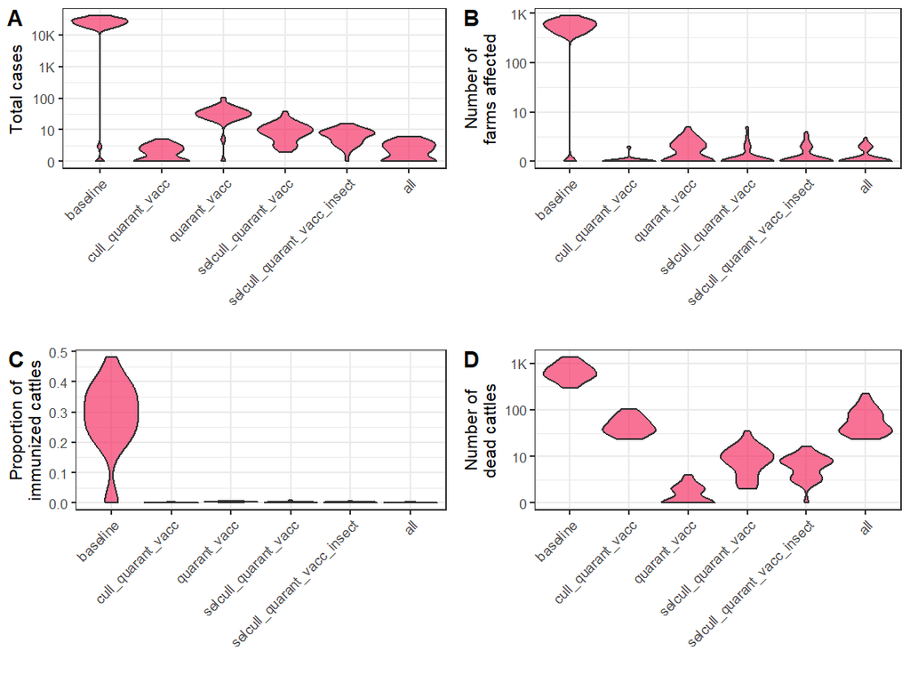

```r
label_numbers <- function(x, show_1_as_0 = FALSE) {
  out <- scales::label_number(scale_cut = scales::cut_long_scale())(x)
  if (show_1_as_0) {
    out[out=="1"] <- "0"
  }
  out
}

p_cases <- ggplot(res, aes(x = scenario, y = total_cases)) +
  geom_violin(scale = "width", fill = "#F5275E", alpha = 0.65) +
  scale_y_continuous(
    transform = "log10",
    labels = function(e) label_numbers(e, show_1_as_0 = TRUE)
  ) +
  theme_bw() +
  labs(
    x = "",
    y = "Total cases"
  )

p_n_pop <- ggplot(res, aes(x = scenario, y = n_pop_ever_infec)) +
  geom_violin(scale = "width", fill = "#F5275E", alpha = 0.65) +
  scale_y_continuous(
    transform = "log10",
    labels = function(e) label_numbers(e, show_1_as_0 = TRUE)
  ) +
  theme_bw() +
  labs(
    x = "",
    y = "Number of\nfarms affected"
    )


p_immun <- ggplot(res, aes(x = scenario, y = p_immun)) +
  geom_violin(scale = "width", fill = "#F5275E", alpha = 0.65) +
  theme_bw() +
  labs(
    x = "",
    y = "Proportion of\nimmunized cattles"
    )

p_dead <- ggplot(res, aes(x = scenario, y = (D+C))) +
  geom_violin(scale = "width", fill = "#F5275E", alpha = 0.65) +
  scale_y_continuous(
    transform = "log10",
    labels = function(e) label_numbers(e, show_1_as_0 = TRUE)
  ) +
  theme_bw() +
  labs(
    x = "",
    y = "Number of\ndead cattles"
  )

rotated_x <- theme(
  axis.text.x = element_text(angle = 45, vjust = 1, hjust=1)
  )

plot_grid(
  p_cases + rotated_x,
  p_n_pop + rotated_x,
  p_immun + rotated_x,
  p_dead + rotated_x,
  labels = LETTERS[1:4]
)
```

Some summary statistics:

```r
# f_smry <- function(x) {
#   out <- c(
#     mean = mean(x),
#     median = median(x),
#     CI_95 = sprintf("[%f;%f]",
#                     quantile(x, 0.025),
#                     quantile(x, 0.975)
#                     )
#   )
# }

# total cases
res %>%
  group_by(scenario) %>%
  summarise(
    mean_cases = mean(total_cases) %>% label_numbers(),
    median_cases = median(total_cases) %>% label_numbers(),
    cases_0.025 = quantile(total_cases, 0.025) %>% label_numbers(),
    cases_0.975 = quantile(total_cases, 0.975) %>% label_numbers(),
    p_greater_100_cases = mean(total_cases >= 100)
  ) %>%
  knitr::kable(digits = 4)
```

| scenario | mean_cases | median_cases | cases_0.025 | cases_0.975 | p_greater_100_cases |
| --- | --- | --- | --- | --- | --- |
| baseline | 24K | 25K | 1 | 38K | 0.9000 |
| cull_quarant_vacc | 2 | 2 | 1 | 4 | 0.0000 |
| quarant_vacc | 34 | 32 | 4 | 69 | 0.0333 |
| selcull_quarant_vacc | 10 | 9 | 3 | 25 | 0.0000 |
| selcull_quarant_vacc_insect | 7 | 7 | 2 | 14 | 0.0000 |
| all | 2 | 2 | 1 | 5 | 0.0000 |

```r
# attack rates
res %>%
  group_by(scenario) %>%
  summarise(
    mean_ar = mean(ar),
    median_ar = median(ar),
    ar_0.025 = quantile(ar, 0.025),
    ar_0.975 = quantile(ar, 0.975)
  ) %>%
  knitr::kable(digits = 4)
```

| scenario | mean_ar | median_ar | ar_0.025 | ar_0.975 |
| --- | --- | --- | --- | --- |
| baseline | 0.2994 | 0.3130 | 0 | 0.4894 |
| cull_quarant_vacc | 0.0000 | 0.0000 | 0 | 0.0001 |
| quarant_vacc | 0.0004 | 0.0004 | 0 | 0.0009 |
| selcull_quarant_vacc | 0.0001 | 0.0001 | 0 | 0.0003 |
| selcull_quarant_vacc_insect | 0.0001 | 0.0001 | 0 | 0.0002 |
| all | 0.0000 | 0.0000 | 0 | 0.0001 |

```r
# deaths
res %>%
  group_by(scenario) %>%
  summarise(
    mean_deaths = mean(C+D) %>% label_numbers(),
    median_deaths = median(C+D) %>% label_numbers(),
    deaths_0.025 = quantile(C+D, 0.025) %>% label_numbers(),
    deaths_0.975 = quantile(C+D, 0.975) %>% label_numbers()
  ) %>%
  knitr::kable()
```

| scenario | mean_deaths | median_deaths | deaths_0.025 | deaths_0.975 |
| --- | --- | --- | --- | --- |
| baseline | 620 | 580 | 0 | 1K |
| cull_quarant_vacc | 49 | 41 | 23 | 95 |
| quarant_vacc | 1 | 1 | 0 | 3 |
| selcull_quarant_vacc | 10 | 9 | 2 | 25 |
| selcull_quarant_vacc_insect | 7 | 7 | 1 | 14 |
| all | 66 | 44 | 24 | 175 |

```r
# farms affected
res %>%
  group_by(scenario) %>%
  summarise(
    mean_farms = mean(n_pop_ever_infec),
    median_farms = median(n_pop_ever_infec),
    farms_0.025 = quantile(n_pop_ever_infec, 0.025),
    farms_0.975 = quantile(n_pop_ever_infec, 0.975)
    ) %>%
  knitr::kable(digits = 2)
```

| scenario | mean_farms | median_farms | farms_0.025 | farms_0.975 |
| --- | --- | --- | --- | --- |
| baseline | 516.57 | 542.5 | 1 | 830.82 |
| cull_quarant_vacc | 1.07 | 1.0 | 1 | 2.00 |
| quarant_vacc | 1.77 | 1.5 | 1 | 3.55 |
| selcull_quarant_vacc | 1.30 | 1.0 | 1 | 3.55 |
| selcull_quarant_vacc_insect | 1.33 | 1.0 | 1 | 3.27 |
| all | 1.27 | 1.0 | 1 | 2.27 |